# Chapter 9 Part II: Ensemble Models

## Bagging (Bootstrap Aggregation)

**Bootstrap** is a resampling technique used in statistics and machine learning to estimate the sampling distribution of a statistic or to assess uncertainty in a dataset. Starting with the original data, we draw multiple **random samples with replacement**, each called a *bootstrap sample*, and each sample has the same size as the original dataset. This process creates many similar but slightly different datasets, allowing us to estimate variability, bias, and confidence intervals of model estimates.

While CART models have many advantages, their main weakness is **high variance**: small changes in the training data can lead to very different trees. **Bagging** (short for *Bootstrap Aggregating*) addresses this by building multiple models on bootstrap samples and averaging their predictions.  
It’s an ensemble learning technique designed to **reduce variance** and improve **predictive stability** and **accuracy** for both regression and classification problems. Bagging is especially effective for **unstable models** like decision trees. By combining many such trees, the ensemble produces smoother, more reliable predictions. However, this comes at the cost of **reduced interpretability**, since the final model is an average of many trees rather than a single, transparent decision tree.

## Mathematical Representation

Suppose we have a training dataset $D = \{(x_i, y_i)\}_{i=1}^n$.  
Bagging generates $B$ bootstrap samples $D^{*(1)}, D^{*(2)}, \ldots, D^{*(B)}$, each drawn with replacement from $D$.

For each bootstrap sample, a base model (e.g., decision tree) $f^{*(b)}(x)$ is fitted.

The final bagging predictor is the **average** (for regression) or **majority vote** (for classification) of all models:

- **Regression:** $$ \hat{f}_{\text{bag}}(x) = \frac{1}{B}\sum_{b=1}^{B} f^{*(b)}(x) $$
- **Classification:** $$ \hat{C}_{\text{bag}}(x) = \text{majority vote}\left( f^{*(1)}(x), f^{*(2)}(x), \ldots, f^{*(B)}(x) \right) $$

As $B \to \infty$, the variance of $\hat{f}_{\text{bag}}(x)$ decreases, while the bias remains roughly the same, leading to improved generalization performance.

## Algorithmic Steps for Bagging

1. **Input:** Training dataset $D = \{(x_i, y_i)\}_{i=1}^n$, number of bootstrap samples $B$.
2. **For** each $b = 1, 2, \ldots, B$:
   - Draw a bootstrap sample $D^{*(b)}$ by sampling $n$ observations *with replacement* from $D$.
   - Fit a base learner (e.g., a decision tree) $f^{*(b)}(x)$ using $D^{*(b)}$.
3. **Aggregate predictions:**
   - For regression: average the predictions.
   - For classification: use majority vote across all models.
4. **Optionally evaluate** model performance using Out-of-Bag (OOB) samples.

### OOB (Out-of-Bag) Data and OOB Error

When building each tree in a bagging ensemble, the algorithm creates a bootstrap sample from the training data — sampling with replacement to form a dataset of the same size as the original. Because some observations are selected multiple times, on average about 63.2% of the training observations appear in each bootstrap sample, while the remaining 36.8% are not selected. These unused observations are called the Out-of-Bag (OOB) samples. Each tree is trained only on its bootstrap sample, and the corresponding OOB data serves as a built-in validation set for that tree. The OOB error is then computed as the average prediction error of the ensemble on all OOB samples, providing an internal estimate of the model’s generalization performance without needing a separate validation set.

| Metric | Meaning | Example Value | Interpretation |
| --- | --- | --- | --- |
| **OOB Error** | Average error rate on out-of-bag samples | 0.215 | 21.5% of OOB samples misclassified |
| **OOB Accuracy** | 1 - OOB Error | 0.785 | 78.5% of OOB samples correctly classified |

Advantages of Bagging

1. **Effective for Large Datasets**  
   Bagging performs especially well on large datasets. When data is abundant, the empirical distribution closely approximates the true population, allowing bootstrap resamples to better capture the underlying patterns and relationships.
2. **Versatility**  
   Bagging is not limited to a specific algorithm—it can be applied to a variety of models (e.g., decision trees, regressions, neural networks), demonstrating strong flexibility across different machine learning methods.
3. **Variance Reduction**  
   The primary goal of bagging is to reduce variance. Under the assumption of independence, averaging over $B$ bootstrap samples reduces variance roughly by a factor of $1/B$, following the Central Limit Theorem.  
   This results in more stable, less overfit predictions.
4. **Out-of-Bag (OOB) Evaluation**  
   Bagging naturally provides a built-in performance evaluation.  
   For each bootstrap sample, about **36.8% of the data is left out** (not selected)—these are called **Out-of-Bag samples**.  
   They act as a built-in test set, allowing accurate performance estimation without additional cross-validation.

Drawbacks of Bagging

1. **Loss of Interpretability**  
   The final model is an average of many trees, not a single interpretable decision tree.  
   While accuracy often improves, understanding how predictions are made becomes more difficult.
2. **Increased Computational Cost**  
   Since bagging fits $B$ separate models, its computational cost is roughly $B$ times that of a single model.  
   This may become significant for large datasets or limited computing resources.
3. **Correlation Among Base Models**  
   The variance reduction benefit of averaging depends on how independent the models are.  
   If the individual trees are highly correlated (e.g., because of similar predictors or dominant features), the overall variance reduction is smaller.  
   Hence, correlation among base models can limit bagging’s effectiveness.

## Example: Bagging in R (Using ipred package)

```r
library(ipred)       # for bagging()
library(caret)
library(rpart)
library(tidyverse)

#Iris dataset
data(iris)
head(iris)
```

A data.frame: 6 × 5

|  | Sepal.Length <dbl> | Sepal.Width <dbl> | Petal.Length <dbl> | Petal.Width <dbl> | Species <fct> |
| --- | --- | --- | --- | --- | --- |
| 1 | 5.1 | 3.5 | 1.4 | 0.2 | setosa |
| 2 | 4.9 | 3.0 | 1.4 | 0.2 | setosa |
| 3 | 4.7 | 3.2 | 1.3 | 0.2 | setosa |
| 4 | 4.6 | 3.1 | 1.5 | 0.2 | setosa |
| 5 | 5.0 | 3.6 | 1.4 | 0.2 | setosa |
| 6 | 5.4 | 3.9 | 1.7 | 0.4 | setosa |

```r
#Split the data into train set and test set
set.seed(252)

index = createDataPartition(iris$Species, p = 0.8, list = FALSE)
train.dat = iris[index,]
test.dat =   iris[-index,]
```

```r
#CART
set.seed(252)   # reproducibility

fit.part = rpart(
  Species ~ .,
  data = train.dat,
  method = "class",
  control = rpart.control(cp = 0.001, minsplit = 5, maxdepth = 4, minbucket=3)
)

#minsplit = 5, minbucket = 3, and maxdepth = 4

yhatrpart = predict(fit.part, newdata = test.dat, type = "class")

# Ensure the prediction factor has the same level order as the observed one
yhat.rpart = factor(yhatrpart, levels = levels(test.dat$Species))

cm = confusionMatrix(data = yhat.rpart, reference = test.dat$Species)

cm
```

```
Confusion Matrix and Statistics

            Reference
Prediction   setosa versicolor virginica
  setosa         10          0         0
  versicolor      0         10         0
  virginica       0          0        10

Overall Statistics

               Accuracy : 1
                 95% CI : (0.8843, 1)
    No Information Rate : 0.3333
    P-Value [Acc > NIR] : 4.857e-15

                  Kappa : 1

 Mcnemar's Test P-Value : NA

Statistics by Class:

                     Class: setosa Class: versicolor Class: virginica
Sensitivity                 1.0000            1.0000           1.0000
Specificity                 1.0000            1.0000           1.0000
Pos Pred Value              1.0000            1.0000           1.0000
Neg Pred Value              1.0000            1.0000           1.0000
Prevalence                  0.3333            0.3333           0.3333
Detection Rate              0.3333            0.3333           0.3333
Detection Prevalence        0.3333            0.3333           0.3333
Balanced Accuracy           1.0000            1.0000           1.0000
```

```r
#bagging

# Fit a bagging model using rpart as the base learner
fit.bag = bagging(
  Species ~ .,
  data = train.dat,,
  nbagg = 50,                     # number of bootstrap samples
  coob = TRUE                     # compute OOB estimate of accuracy
)

# Model summary
fit.bag

yhatbagging= predict(fit.bag, newdata = test.dat, type = "class")

# Ensure the prediction factor has the same level order as the observed one
yhat.bagging = factor(yhatbagging, levels = levels(test.dat$Species))

cm.2 = confusionMatrix(data = yhat.bagging, reference = test.dat$Species)

cm.2
```

```
Bagging classification trees with 50 bootstrap replications

Call: bagging.data.frame(formula = Species ~ ., data = train.dat, nbagg = 50,
    coob = TRUE)

Out-of-bag estimate of misclassification error:  0.0583
```

```
Confusion Matrix and Statistics

            Reference
Prediction   setosa versicolor virginica
  setosa         10          0         0
  versicolor      0         10         1
  virginica       0          0         9

Overall Statistics

               Accuracy : 0.9667
                 95% CI : (0.8278, 0.9992)
    No Information Rate : 0.3333
    P-Value [Acc > NIR] : 2.963e-13

                  Kappa : 0.95

 Mcnemar's Test P-Value : NA

Statistics by Class:

                     Class: setosa Class: versicolor Class: virginica
Sensitivity                 1.0000            1.0000           0.9000
Specificity                 1.0000            0.9500           1.0000
Pos Pred Value              1.0000            0.9091           1.0000
Neg Pred Value              1.0000            1.0000           0.9524
Prevalence                  0.3333            0.3333           0.3333
Detection Rate              0.3333            0.3333           0.3000
Detection Prevalence        0.3333            0.3667           0.3000
Balanced Accuracy           1.0000            0.9750           0.9500
```

```r
# 1) Set seed for reproducibility
set.seed(521)

# 2) Define 10-fold cross-validation
ctrl = trainControl(
  method = "cv",      # cross-validation
  number = 10         # 10 folds
)

# 3) Train a CART model using rpart
fit.tbag = train(
  Species ~ .,
  data = train.dat,
  method = "treebag",   # bagging method
  trControl = ctrl,   # cross-validation setup
  tuneLength = 20     # number of cp (complexity parameter) values to try
)

fit.tbag$bestTune

yhattbag= predict(fit.tbag, newdata = test.dat, type = "raw")

# Ensure the prediction factor has the same level order as the observed one
yhat.tbag = factor(yhattbag, levels = levels(test.dat$Species))

cm.3 = confusionMatrix(data = yhat.tbag, reference = test.dat$Species)

cm.3
```

A data.frame: 1 × 1

|  | parameter <chr> |
| --- | --- |
| 1 | none |

```
Confusion Matrix and Statistics

            Reference
Prediction   setosa versicolor virginica
  setosa         10          0         0
  versicolor      0         10         1
  virginica       0          0         9

Overall Statistics

               Accuracy : 0.9667
                 95% CI : (0.8278, 0.9992)
    No Information Rate : 0.3333
    P-Value [Acc > NIR] : 2.963e-13

                  Kappa : 0.95

 Mcnemar's Test P-Value : NA

Statistics by Class:

                     Class: setosa Class: versicolor Class: virginica
Sensitivity                 1.0000            1.0000           0.9000
Specificity                 1.0000            0.9500           1.0000
Pos Pred Value              1.0000            0.9091           1.0000
Neg Pred Value              1.0000            1.0000           0.9524
Prevalence                  0.3333            0.3333           0.3333
Detection Rate              0.3333            0.3333           0.3000
Detection Prevalence        0.3333            0.3667           0.3000
Balanced Accuracy           1.0000            0.9750           0.9500
```

Example:

Build a predictive model using **bagging** to classify the `diabetes` variable in the **PimaIndiansDiabetes** dataset (from the `mlbench` package).

### Instructions

```r
# ============================================================

library(ipred)       # for bagging()
library(caret)
library(rpart)

 library(MASS) #Modern Applied Statistics with S
 library(mlbench) #data sets from the UCI repository.

data(PimaIndiansDiabetes)
dat = PimaIndiansDiabetes

str(dat)

set.seed(527)

# Train-test split (80/20)
train_index = createDataPartition(dat$diabetes, p = 0.8, list = FALSE)
train.dat = dat[train_index, ]
test.dat  = dat[-train_index, ]
```

```
'data.frame':	768 obs. of  9 variables:
 $ pregnant: num  6 1 8 1 0 5 3 10 2 8 ...
 $ glucose : num  148 85 183 89 137 116 78 115 197 125 ...
 $ pressure: num  72 66 64 66 40 74 50 0 70 96 ...
 $ triceps : num  35 29 0 23 35 0 32 0 45 0 ...
 $ insulin : num  0 0 0 94 168 0 88 0 543 0 ...
 $ mass    : num  33.6 26.6 23.3 28.1 43.1 25.6 31 35.3 30.5 0 ...
 $ pedigree: num  0.627 0.351 0.672 0.167 2.288 ...
 $ age     : num  50 31 32 21 33 30 26 29 53 54 ...
 $ diabetes: Factor w/ 2 levels "neg","pos": 2 1 2 1 2 1 2 1 2 2 ...
```

```r
# Fit a bagging model using rpart as the base learner
fit.bag = bagging(
  diabetes ~ .,
  data = train.dat,
  nbagg = 100,                     # number of bootstrap samples
  coob = TRUE                     # compute OOB estimate of accuracy
)

# Model summary
fit.bag

# OOB error estimate and accuracy
print(paste("OOB accuracy:", round(1 - fit.bag$err, 4)))

# Predict on test data
pred.bag = predict(fit.bag, newdata = test.dat, type = "class")

# Confusion matrix
confusionMatrix(pred.bag, test.dat$diabetes)
```

```
Bagging classification trees with 100 bootstrap replications

Call: bagging.data.frame(formula = diabetes ~ ., data = train.dat,
    nbagg = 100, coob = TRUE)

Out-of-bag estimate of misclassification error:  0.252
```

```
[1] "OOB accuracy: 0.748"
```

```
Confusion Matrix and Statistics

          Reference
Prediction neg pos
       neg  80  20
       pos  20  33

               Accuracy : 0.7386
                 95% CI : (0.6615, 0.8062)
    No Information Rate : 0.6536
    P-Value [Acc > NIR] : 0.01536

                  Kappa : 0.4226

 Mcnemar's Test P-Value : 1.00000

            Sensitivity : 0.8000
            Specificity : 0.6226
         Pos Pred Value : 0.8000
         Neg Pred Value : 0.6226
             Prevalence : 0.6536
         Detection Rate : 0.5229
   Detection Prevalence : 0.6536
      Balanced Accuracy : 0.7113

       'Positive' Class : neg
```

```r
#Use the train function in caret package for bagging
set.seed(527)
#Cross validation :  10 folder cross validation
ctrl  =  trainControl(method  = "cv", number  = 10)

fit.bagging1 =  train(diabetes ~ ., data = train.dat,
                     method = "treebag", trControl = ctrl, tuneLength =20)


#Train a bagging model
fit.bagging2 = train(
  diabetes ~ .,   data = train.dat, method = "treebag",
  trControl = trainControl(method = "cv", number = 10),  #cross validation setting
  nbagg = 100,
  control = rpart.control(minsplit = 2, cp = 0)
)
```

[output not shown]

```r
fit.bagging1

fit.bagging2

#


# Predict on test data
pred.bag1 = predict(fit.bagging1, newdata = test.dat, type = "raw")

# Confusion matrix
confusionMatrix(pred.bag1, test.dat$diabetes)


# Predict on test data
pred.bag2 = predict(fit.bagging2, newdata = test.dat, type = "raw")

# Confusion matrix
confusionMatrix(pred.bag2, test.dat$diabetes)
```

```
Bagged CART

615 samples
  8 predictor
  2 classes: 'neg', 'pos'

No pre-processing
Resampling: Cross-Validated (10 fold)
Summary of sample sizes: 553, 553, 553, 554, 553, 554, ...
Resampling results:

  Accuracy  Kappa
  0.754495  0.460498
```

```
Bagged CART

615 samples
  8 predictor
  2 classes: 'neg', 'pos'

No pre-processing
Resampling: Cross-Validated (10 fold)
Summary of sample sizes: 554, 554, 554, 553, 554, 553, ...
Resampling results:

  Accuracy   Kappa
  0.7676626  0.479333
```

```
Confusion Matrix and Statistics

          Reference
Prediction neg pos
       neg  82  23
       pos  18  30

               Accuracy : 0.732
                 95% CI : (0.6545, 0.8003)
    No Information Rate : 0.6536
    P-Value [Acc > NIR] : 0.02367

                  Kappa : 0.3948

 Mcnemar's Test P-Value : 0.53217

            Sensitivity : 0.8200
            Specificity : 0.5660
         Pos Pred Value : 0.7810
         Neg Pred Value : 0.6250
             Prevalence : 0.6536
         Detection Rate : 0.5359
   Detection Prevalence : 0.6863
      Balanced Accuracy : 0.6930

       'Positive' Class : neg
```

```
Confusion Matrix and Statistics

          Reference
Prediction neg pos
       neg  80  21
       pos  20  32

               Accuracy : 0.732
                 95% CI : (0.6545, 0.8003)
    No Information Rate : 0.6536
    P-Value [Acc > NIR] : 0.02367

                  Kappa : 0.4056

 Mcnemar's Test P-Value : 1.00000

            Sensitivity : 0.8000
            Specificity : 0.6038
         Pos Pred Value : 0.7921
         Neg Pred Value : 0.6154
             Prevalence : 0.6536
         Detection Rate : 0.5229
   Detection Prevalence : 0.6601
      Balanced Accuracy : 0.7019

       'Positive' Class : neg
```

# Random Forests

The **Random Forest** algorithm, introduced by *Leo Breiman* and *Adele Cutler (2001)*, is one of the most powerful and widely used ensemble learning methods in machine learning. It extends the concept of **Bagging (Bootstrap Aggregation)** by adding an additional layer of randomness. Not only does each decision tree in the ensemble use a different bootstrap sample of the data, but at each split, the algorithm also considers a **random subset of predictor variables**.

This dual randomness, sampling both **data points** and **features**, produces a *forest* of diverse and uncorrelated trees. By aggregating their predictions, Random Forest achieves strong predictive performance, stability, and robustness, making it one of the best general-purpose algorithms for both **classification** and **regression** tasks.

The Random Forest algorithm combines the strength of multiple decision trees using both bootstrap sampling and random feature selection, resulting in a powerful, stable, and accurate ensemble model. It effectively reduces variance and overfitting compared to single decision trees and provides useful measures such as OOB error and feature importance. Although less interpretable and more computationally demanding, Random Forest remains a top choice for most applied machine learning problems due to its robustness, accuracy, and minimal tuning requirements.

How Random Forests Work

In a **classification** Random Forest, multiple decision trees are constructed using different random subsets of both the data and the features. Each tree acts as an independent classifier, producing its own prediction. The final prediction is made by **majority vote** across all trees.

For **regression**, the final prediction is the **average** of the predictions from all trees.

Algorithmic Steps

1. **Bootstrap Sampling**  
   Draw ( B ) bootstrap samples from the training data. Each sample is drawn *with replacement*, typically containing about 63% of the original data.
2. **Tree Construction (Random Feature Selection)**  
   For each bootstrap sample:
   - At every split, randomly select ( m ) out of the total ( p ) features (where ( m < p )).
   - The best split is determined **only among those ( m ) features**, introducing randomness and decorrelation among trees.
3. **Tree Growth**  
   Each tree is grown fully without pruning (max depth).
4. **Prediction Aggregation**
   - **Classification:** use the *majority vote* among trees.
   - **Regression:** use the *average* of predicted values.

Let ( f_b(x) ) denote the prediction from the ( b )-th tree, for ( b = 1, 2, \ldots, B ).

By averaging across many de-correlated trees, Random Forests achieve a large reduction in variance without a corresponding increase in bias.

Features of Random Forest

- **Aggregation of Multiple Decision Trees:**  
  Random Forest builds an ensemble of many decision trees, combining their predictions to create a single, more robust output.
- **Random Feature Selection:**  
  At each split, only a subset of predictors is considered, which reduces correlation between trees and improves generalization.
- **Inherent Out-of-Bag (OOB) Evaluation:**  
  About 36.8% of the observations are left out of each bootstrap sample. These are used to estimate the OOB error, which serves as an unbiased estimate of model accuracy without needing a separate test set.

### Advantages of Random Forest

- **High Predictive Accuracy:**  
  Averaging many uncorrelated trees results in a powerful model that outperforms a single decision tree in most cases.
- **Built-in Validation (OOB Error):**  
  The OOB samples provide a natural estimate of test error, eliminating the need for cross-validation.
- **Robust to Overfitting:**  
  The randomness in both data sampling and feature selection prevents the model from memorizing noise.
- **Handles Large Feature Spaces:**  
  Works well with high-dimensional data and can estimate feature importance.
- **Resistant to Missing Data:**  
  Can maintain predictive power even when some predictors are missing.

### Disadvantages of Random Forest

- **Loss of Interpretability:**  
  The ensemble nature makes it less transparent than a single decision tree.
- **Computational Cost:**  
  Training hundreds of trees can be computationally intensive, requiring more memory and processing power.
- **Limited Extrapolation in Regression:**  
  Like decision trees, random forests cannot predict beyond the range of observed data.

## Random Forest Implementation in R

In R, the **`randomForest`** package (Breiman & Cutler) is commonly used to create Random Forest models.  
The function `randomForest()` fits the model and provides built-in OOB error estimation and feature importance.

```r
library(MASS) #Modern Applied Statistics with S
library(mlbench) #data sets from the UCI repository.
library(randomForest)
library(caret)

data(PimaIndiansDiabetes)
dat = PimaIndiansDiabetes

str(dat)

set.seed(527)

# Train-test split (80/20)
train_index = createDataPartition(dat$diabetes, p = 0.8, list = FALSE)
train.dat = dat[train_index, ]
test.dat  = dat[-train_index, ]
```

```
'data.frame':	768 obs. of  9 variables:
 $ pregnant: num  6 1 8 1 0 5 3 10 2 8 ...
 $ glucose : num  148 85 183 89 137 116 78 115 197 125 ...
 $ pressure: num  72 66 64 66 40 74 50 0 70 96 ...
 $ triceps : num  35 29 0 23 35 0 32 0 45 0 ...
 $ insulin : num  0 0 0 94 168 0 88 0 543 0 ...
 $ mass    : num  33.6 26.6 23.3 28.1 43.1 25.6 31 35.3 30.5 0 ...
 $ pedigree: num  0.627 0.351 0.672 0.167 2.288 ...
 $ age     : num  50 31 32 21 33 30 26 29 53 54 ...
 $ diabetes: Factor w/ 2 levels "neg","pos": 2 1 2 1 2 1 2 1 2 2 ...
```

```
Call:
 randomForest(formula = diabetes ~ ., data = train.dat, ntree = 200,      mtry = 2, importance = TRUE)
               Type of random forest: classification
                     Number of trees: 200
No. of variables tried at each split: 2

        OOB estimate of  error rate: 24.39%
Confusion matrix:
    neg pos class.error
neg 339  61   0.1525000
pos  89 126   0.4139535
OOB Error Rate: 24.39 %
```

```
Confusion Matrix and Statistics

          Reference
Prediction neg pos
       neg  86  23
       pos  14  30

               Accuracy : 0.7582
                 95% CI : (0.6824, 0.8237)
    No Information Rate : 0.6536
    P-Value [Acc > NIR] : 0.003479

                  Kappa : 0.4437

 Mcnemar's Test P-Value : 0.188445

            Sensitivity : 0.8600
            Specificity : 0.5660
         Pos Pred Value : 0.7890
         Neg Pred Value : 0.6818
             Prevalence : 0.6536
         Detection Rate : 0.5621
   Detection Prevalence : 0.7124
      Balanced Accuracy : 0.7130

       'Positive' Class : neg
```

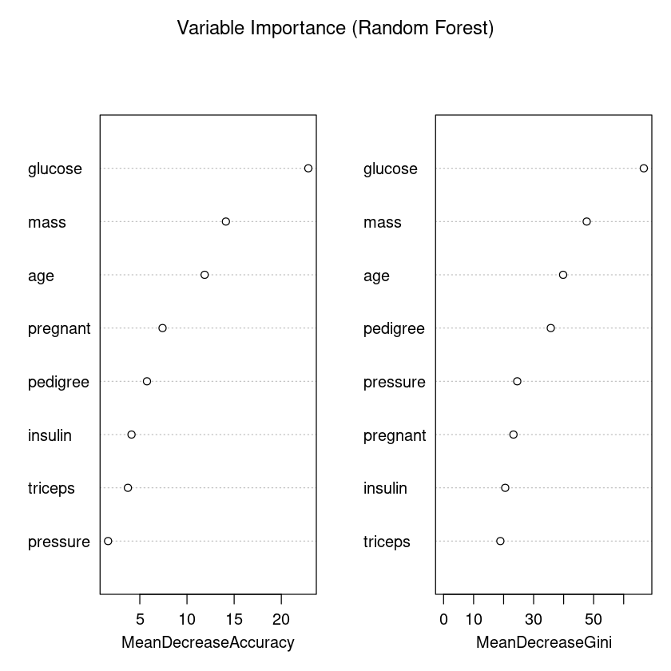

```r
# Fit random forest model
fit.rf = randomForest(
  diabetes ~ .,
  data = train.dat,
  ntree = 200,          # number of trees
  mtry = 2,             # number of features to try at each split
  importance = TRUE
)

# Print model summary
print(fit.rf)

#OOB error rate
cat("OOB Error Rate:", round(fit.rf$err.rate[nrow(fit.rf$err.rate), "OOB"] * 100, 2), "%\n")

# Predict on test data
pred.rf = predict(fit.rf, newdata = test.dat)
confusionMatrix(pred.rf, test.dat$diabetes)

# Feature importance plot
varImpPlot(fit.rf, main = "Variable Importance (Random Forest)")
```

The importance of variables: glucose is the most useful variable in the model.

This Variable Importance Plot from the Random Forest model shows how much each predictor contributes to accurate classification. The left panel (MeanDecreaseAccuracy) measures how much overall model accuracy decreases when each variable’s values are randomly permuted. A larger decrease means that the variable is more important for prediction. The right panel (MeanDecreaseGini) reflects the total reduction in node impurity (Gini index) contributed by each variable across all trees — higher values indicate greater importance in splitting decisions.

```r
#Model tuning via R caret train function
set.seed(738)
#mtry : the number of variables to randomly sample as candidates at each split.
#When mtry = the number of features. the random forest model equates to bagging.
        tune.grid = expand.grid(.mtry = 2:3)
        trcn = trainControl(method = "cv", number = 5)

        #Train a rf model by selecting the optimal tuning paramter
        rf.fit = train( diabetes ~ ., data = train.dat,
                   method = 'rf',
                   tuneGrid = tune.grid,
                   metric = "Accuracy",                 # for multi-class; also use "Kappa"
   #                preProcess = c("center", "scale"),    # standardization helps
                   trControl = trcn)

   #    rf.fit$besttunes

# Predict on test data
pred.rf1 = predict(rf.fit, newdata = test.dat, type = "raw")

# Confusion matrix
confusionMatrix(pred.rf1, test.dat$diabetes)
```

```
Confusion Matrix and Statistics

          Reference
Prediction neg pos
       neg  82  24
       pos  18  29

               Accuracy : 0.7255
                 95% CI : (0.6476, 0.7945)
    No Information Rate : 0.6536
    P-Value [Acc > NIR] : 0.03543

                  Kappa : 0.3772

 Mcnemar's Test P-Value : 0.44040

            Sensitivity : 0.8200
            Specificity : 0.5472
         Pos Pred Value : 0.7736
         Neg Pred Value : 0.6170
             Prevalence : 0.6536
         Detection Rate : 0.5359
   Detection Prevalence : 0.6928
      Balanced Accuracy : 0.6836

       'Positive' Class : neg
```

```
Call:
 randomForest(formula = Species ~ ., data = train.dat, ntree = 200,      mtry = 2, importance = TRUE)
               Type of random forest: classification
                     Number of trees: 200
No. of variables tried at each split: 2

        OOB estimate of  error rate: 5.83%
Confusion matrix:
           setosa versicolor virginica class.error
setosa         40          0         0       0.000
versicolor      0         37         3       0.075
virginica       0          4        36       0.100
OOB Error Rate: 5.83 %
```

```
Confusion Matrix and Statistics

            Reference
Prediction   setosa versicolor virginica
  setosa         10          0         0
  versicolor      0         10         2
  virginica       0          0         8

Overall Statistics

               Accuracy : 0.9333
                 95% CI : (0.7793, 0.9918)
    No Information Rate : 0.3333
    P-Value [Acc > NIR] : 8.747e-12

                  Kappa : 0.9

 Mcnemar's Test P-Value : NA

Statistics by Class:

                     Class: setosa Class: versicolor Class: virginica
Sensitivity                 1.0000            1.0000           0.8000
Specificity                 1.0000            0.9000           1.0000
Pos Pred Value              1.0000            0.8333           1.0000
Neg Pred Value              1.0000            1.0000           0.9091
Prevalence                  0.3333            0.3333           0.3333
Detection Rate              0.3333            0.3333           0.2667
Detection Prevalence        0.3333            0.4000           0.2667
Balanced Accuracy           1.0000            0.9500           0.9000
```

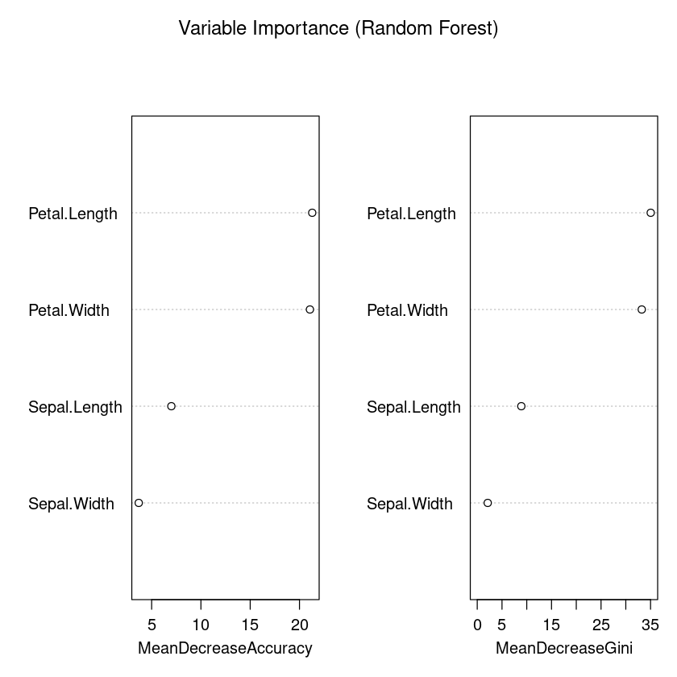

```r
library(randomForest)
library(caret)

set.seed(527)

# Train-test split
train_index = createDataPartition(iris$Species, p = 0.8, list = FALSE)
train.dat = iris[train_index, ]
test.dat  = iris[-train_index, ]

# Fit random forest model
fit.rf = randomForest(
  Species ~ .,
  data = train.dat,
  ntree = 200,          # number of trees
  mtry = 2,             # number of features to try at each split
  importance = TRUE
)

# Print model summary
print(fit.rf)

# OOB error rate
cat("OOB Error Rate:", round(fit.rf$err.rate[nrow(fit.rf$err.rate), "OOB"] * 100, 2), "%\n")

# Predict on test data
pred.rf = predict(fit.rf, newdata = test.dat)
confusionMatrix(pred.rf, test.dat$Species)

# Feature importance plot
varImpPlot(fit.rf, main = "Variable Importance (Random Forest)")
```

This Variable Importance Plot from the Random Forest model on the iris dataset shows how much each predictor contributes to accurate classification. The left panel (MeanDecreaseAccuracy) measures how much overall model accuracy decreases when each variable’s values are randomly permuted. A larger decrease means that the variable is more important for prediction. The right panel (MeanDecreaseGini) reflects the total reduction in node impurity (Gini index) contributed by each variable across all trees — higher values indicate greater importance in splitting decisions.

Petal.Length and Petal.Width are by far the most important predictors for distinguishing among the three iris species. Sepal.Length has moderate importance, while Sepal.Width contributes very little to the model’s predictive power. This result aligns with the known biology of the dataset — petal measurements are the strongest discriminators between species such as setosa, versicolor, and virginica.

A data.frame: 6 × 6

|  | left daughter <dbl> | right daughter <dbl> | split var <fct> | split point <dbl> | status <dbl> | prediction <chr> |
| --- | --- | --- | --- | --- | --- | --- |
| 1 | 2 | 3 | Sepal.Length | 5.55 | 1 | NA |
| 2 | 4 | 5 | Sepal.Width | 2.80 | 1 | NA |
| 3 | 6 | 7 | Sepal.Length | 6.25 | 1 | NA |
| 4 | 8 | 9 | Petal.Length | 4.25 | 1 | NA |
| 5 | 0 | 0 | NA | 0.00 | -1 | setosa |
| 6 | 10 | 11 | Petal.Length | 4.80 | 1 | NA |

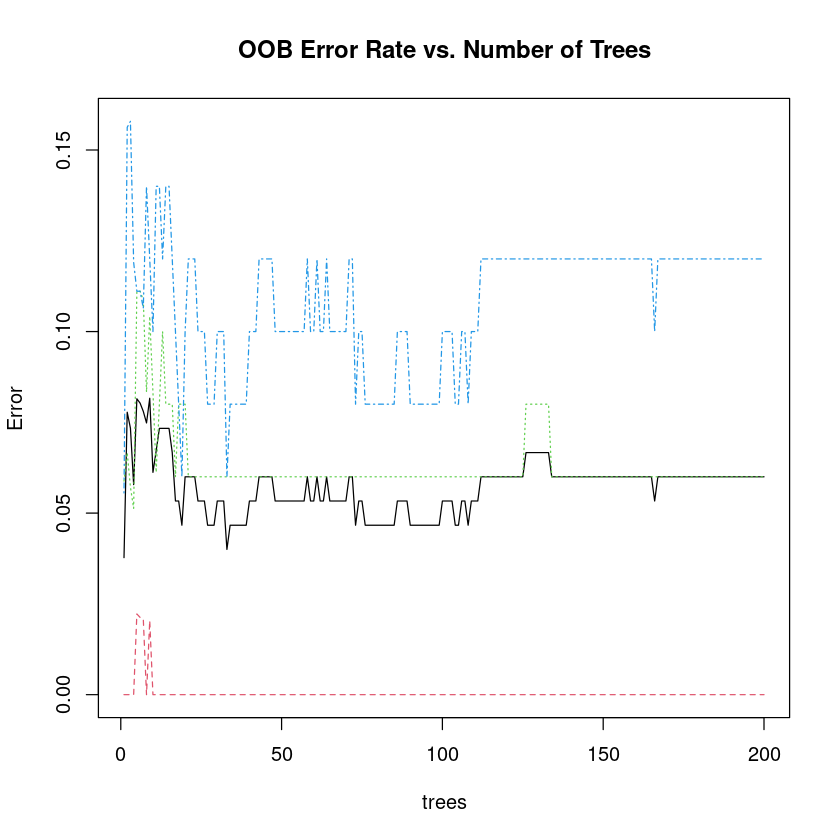

```r
library(randomForest)
library(rpart.plot)

set.seed(527)
fit.rf = randomForest(Species ~ ., data = iris, ntree = 200)

# Extract a single tree (e.g., the 5th)
tree5 = getTree(fit.rf, k = 5, labelVar = TRUE)
head(tree5)

plot(fit.rf, main = "OOB Error Rate vs. Number of Trees")
```

The OOB error typically decreases and stabilizes as the forest grows. The “elbow” point indicates where adding more trees yields diminishing returns.

### Key tuning hyperparameters for Random Forests

1. **`ntree`** — number of trees.
   - More trees ↓ variance and stabilize OOB error; compute grows roughly linearly.
   - Typical ranges: **300–1000** (often 500 is fine once OOB error plateaus).
2. **`mtry`** — number of candidate predictors tried at each split.
   - **Defaults:** `sqrt(p)` (classification), `p/3` (regression).
   - `mtry = p` ≈ **bagging** (trees become more correlated, higher variance).
   - `mtry = 1` maximizes de-correlation but can increase bias.
   - Practical tip: search a **small grid** around the default (e.g., ±50%).
3. **`sampsize`** — size of the bootstrap sample *per tree*.
   - **Default:** draws `n` rows *with replacement*; ~**63.2%** of rows are unique in each bootstrap sample (the rest are duplicates).
   - You may set a fraction (e.g., `sampsize = 0.7*n`) for faster training; smaller values ↑ bias, larger values ↑ variance/cost.
   - For **classification**, you can pass a **vector** to balance classes.
4. **`nodesize`** — minimum observations in a terminal node (controls tree depth).
   - **Defaults:** `1` (classification), `5` (regression).
   - Smaller → deeper trees (↓ bias, ↑ variance). Larger → shallower trees (↑ bias, ↓ variance).
5. **`maxnodes`** — hard cap on the number of terminal nodes.
   - Another knob to limit depth/complexity; leaving it `NULL` is common unless you need extra regularization.

> General workflow: start with defaults, **tune `mtry` first**, then consider `nodesize`/`sampsize`; increase `ntree` until the OOB curve flattens.

### Initial tuning with `randomForest::tuneRF` (regression)

The helper `tuneRF()` searches for a good `mtry` by tracking OOB error.

```r
#Use randomforest to build a model to predict "house price" using othe varialbes in the data.

# Use the boston housing data
library(MASS)
library(tidyverse)
library(caret)
library(randomForest)

#There are 14 varables:  medv is the price of house (response)
data(Boston)
str(Boston)

set.seed(252)

index = createDataPartition(Boston$medv, p = 0.8, list = FALSE)
train.dat = Boston[index,]
test.dat =   Boston[-index,]
```

```
'data.frame':	506 obs. of  14 variables:
 $ crim   : num  0.00632 0.02731 0.02729 0.03237 0.06905 ...
 $ zn     : num  18 0 0 0 0 0 12.5 12.5 12.5 12.5 ...
 $ indus  : num  2.31 7.07 7.07 2.18 2.18 2.18 7.87 7.87 7.87 7.87 ...
 $ chas   : int  0 0 0 0 0 0 0 0 0 0 ...
 $ nox    : num  0.538 0.469 0.469 0.458 0.458 0.458 0.524 0.524 0.524 0.524 ...
 $ rm     : num  6.58 6.42 7.18 7 7.15 ...
 $ age    : num  65.2 78.9 61.1 45.8 54.2 58.7 66.6 96.1 100 85.9 ...
 $ dis    : num  4.09 4.97 4.97 6.06 6.06 ...
 $ rad    : int  1 2 2 3 3 3 5 5 5 5 ...
 $ tax    : num  296 242 242 222 222 222 311 311 311 311 ...
 $ ptratio: num  15.3 17.8 17.8 18.7 18.7 18.7 15.2 15.2 15.2 15.2 ...
 $ black  : num  397 397 393 395 397 ...
 $ lstat  : num  4.98 9.14 4.03 2.94 5.33 ...
 $ medv   : num  24 21.6 34.7 33.4 36.2 28.7 22.9 27.1 16.5 18.9 ...
```

```
Call:
 randomForest(formula = medv ~ ., data = train.dat)
               Type of random forest: regression
                     Number of trees: 500
No. of variables tried at each split: 4

          Mean of squared residuals: 10.822
                    % Var explained: 87.33
```

2.85532054025289

A data.frame: 13 × 1

|  | Overall <dbl> |
| --- | --- |
| crim | 1997.7488 |
| zn | 208.2695 |
| indus | 1852.8839 |
| chas | 277.1691 |
| nox | 2387.4654 |
| rm | 8673.7852 |
| age | 994.3108 |
| dis | 2203.7450 |
| rad | 278.9610 |
| tax | 1021.3600 |
| ptratio | 2165.8449 |
| black | 589.9804 |
| lstat | 11589.6735 |

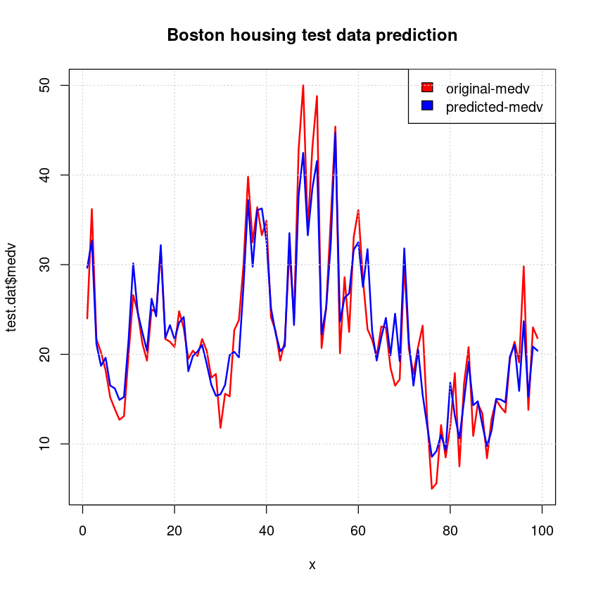

```r
set.seed(3523)
fit.randomf = randomForest(medv ~ ., data = train.dat)
fit.randomf
yhat = predict(fit.randomf, test.dat)

#RMSE
caret::RMSE(test.dat$medv, yhat)

#Variable importance
varImp(fit.randomf)

#Line plots to see the performance
#Predicted value vs observed values
x = 1:length(yhat)
plot(x, test.dat$medv, col = "red", type = "l", lwd=2,
     main = "Boston housing test data prediction")
lines(x, yhat, col = "blue", lwd=2)
legend("topright",  legend = c("original-medv", "predicted-medv"),
       fill = c("red", "blue"), col = 2:3,  adj = c(0, 0.6))
grid()
```

```r
#Model tuning via R caret train function
set.seed(738)
#mtry : the number of variables to randomly sample as candidates at each split.
#When mtry = the number of features. the random forest model equates to bagging.
        tune.grid = expand.grid(.mtry = 1:10)
        trcn = trainControl(method = "cv", number = 5)

        #Train a rf model by selecting the optimal tuning paramter
        rf.fit2 = train(medv ~ ., data = train.dat,
                   method = 'rf',
                   tuneGrid = tune.grid,
                   trControl = trcn)
```

```r
rf.fit2

#The best tuning paramter
rf.fit2$bestTune
```

```
Random Forest

407 samples
 13 predictor

No pre-processing
Resampling: Cross-Validated (5 fold)
Summary of sample sizes: 325, 326, 325, 326, 326
Resampling results across tuning parameters:

  mtry  RMSE      Rsquared   MAE
   1    4.736969  0.7831360  3.091941
   2    3.874854  0.8391755  2.473898
   3    3.652660  0.8518904  2.339500
   4    3.572725  0.8559334  2.311195
   5    3.505582  0.8594620  2.280824
   6    3.467662  0.8616303  2.261250
   7    3.422664  0.8648375  2.242138
   8    3.415299  0.8650235  2.236861
   9    3.472668  0.8594367  2.266206
  10    3.438088  0.8625482  2.252171

RMSE was used to select the optimal model using the smallest value.
The final value used for the model was mtry = 8.
```

A data.frame: 1 × 1

|  | mtry <int> |
| --- | --- |
| 8 | 8 |

```r
yhat = predict(rf.fit2, test.dat)
#RMSE
caret::RMSE(test.dat$medv, yhat)

#Which is better than the random forest model without tuning
```

2.73065784344278

```
mtry = 4  OOB error = 10.458
Searching left ...
mtry = 3 	OOB error = 11.41172
-0.09119558 0.01
Searching right ...
mtry = 6 	OOB error = 10.21688
0.0230558 0.01
mtry = 9 	OOB error = 10.18068
0.003543024 0.01

Best mtry from tuneRF: 9

Tuning Results (sorted by OOB_MSE):
  ntree mtry nodesize  OOB_MSE    OOB_R2
1   500    9        5 10.12055 0.8814932
4  1000    9        5 10.14448 0.8812130
2   500    9       10 10.62869 0.8755432
5  1000    9       10 10.88929 0.8724917
6  1000    9       20 11.25637 0.8681934
3   500    9       20 11.30415 0.8676339
OOB MSE=10.121, OOB R2=0.881
Test RMSE=2.684, Test R2=0.913
```

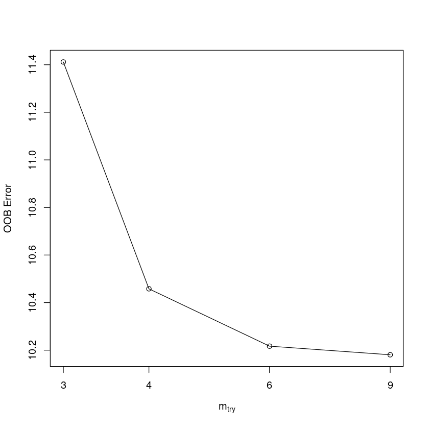

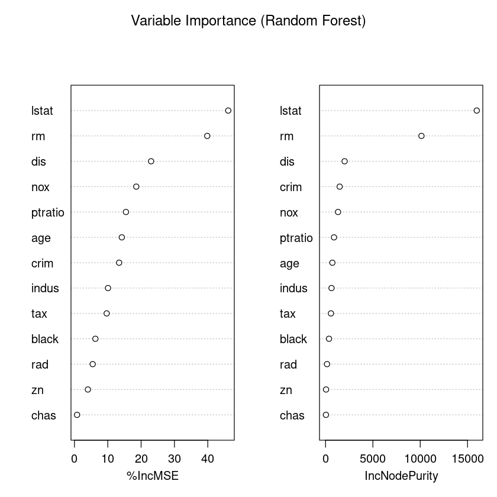

```r
set.seed(6021)

# Response and predictors
y_train = train.dat$medv
x_train = train.dat[, setdiff(names(train.dat), "medv")]
y_test  = test.dat$medv
x_test  = test.dat[, setdiff(names(test.dat), "medv")]

#------------------------------------------------------------
# 2. Initial tuning of mtry using tuneRF
#------------------------------------------------------------
set.seed(6021)
p = ncol(x_train)

tune.out = tuneRF(
  x = x_train,
  y = y_train,
  mtryStart = floor(p/3),
  stepFactor = 1.5,
  improve = 0.01,
  ntreeTry = 400,
  trace = TRUE,
  plot = TRUE,
  doBest = FALSE
)

best.mtry = tune.out[which.min(tune.out[, "OOBError"]), "mtry"]
cat("\nBest mtry from tuneRF:", best.mtry, "\n")

#------------------------------------------------------------
# 3. Fit random forests with small grid search
#------------------------------------------------------------
ntree.grid = c(500, 1000)
nodesize.grid = c(5, 10, 20)

results = data.frame(ntree = integer(), mtry = integer(),
                     nodesize = integer(), OOB_MSE = numeric(),
                     OOB_R2 = numeric())

best.model = NULL
best.oob = Inf

for (nt in ntree.grid) {
  for (ns in nodesize.grid) {
    set.seed(6021)
    rf.fit = randomForest(
      x = x_train, y = y_train,
      ntree = nt,
      mtry = best.mtry,
      nodesize = ns,
      importance = TRUE,
      replace = TRUE,
      keep.inbag = TRUE
    )

    oob.mse = tail(rf.fit$mse, 1)
    oob.r2  = tail(rf.fit$rsq, 1)

    results = rbind(results,
                    data.frame(ntree = nt, mtry = best.mtry,
                               nodesize = ns, OOB_MSE = oob.mse,
                               OOB_R2 = oob.r2))

    if (oob.mse < best.oob) {
      best.oob = oob.mse
      best.model = rf.fit
    }
  }
}

cat("\nTuning Results (sorted by OOB_MSE):\n")
print(results[order(results$OOB_MSE), ])

#------------------------------------------------------------
# 4. Evaluate best model on test data
#------------------------------------------------------------
yhat = predict(best.model, newdata = x_test)
rmse = sqrt(mean((yhat - y_test)^2))
r2   = cor(yhat, y_test)^2

cat(sprintf("\nBest Model: ntree=%d, mtry=%d, nodesize=%d\n",
            best.model$ntree, best.model$mtry, best.model$nodesize))
cat(sprintf("OOB MSE=%.3f, OOB R2=%.3f\n",
            tail(best.model$mse, 1), tail(best.model$rsq, 1)))
cat(sprintf("Test RMSE=%.3f, Test R2=%.3f\n", rmse, r2))

#------------------------------------------------------------
# 5. Variable importance and partial dependence
#------------------------------------------------------------
varImpPlot(best.model, main = "Variable Importance (Random Forest)")

# Partial dependence for top variable
top.var = names(importance(best.model, type = 1))[which.max(importance(best.model, type = 1))]
#partialPlot(best.model, pred.data = train.dat, x.var = top.var,
#            main = paste("Partial Dependence on", top.var))

#A random forest was trained with mtry = 4, meaning 4 predictor variables were randomly selected as candidates for splitting at each node.
#The out-of-bag (OOB) mean squared error (MSE) was 10.458
```